Coding Essentials for Astronomers

# SkyField for Precision Ephemerides

## Introduction

In Lecture 14, you learned how to plan observations using Astropy. You computed Sun and Moon positions with `get_sun()` and `get_body()`, transformed coordinates to your local horizon system with AltAz frames, and created visibility plots showing when targets are observable. These tools work well for observation planning where positions accurate to a few arcseconds are sufficient.

But here's a question you might not have considered: **How does Astropy know where Jupiter will be on October 20, 2025?** Or more fundamentally, **why can't we just calculate planetary positions from scratch whenever we need them?**

The answer involves one of astronomy's oldest and most challenging problems. Newton's laws of gravity work beautifully for two bodies. Earth orbiting the Sun follows a perfect ellipse that we can predict exactly with a simple mathematical formula. But the solar system contains eight planets, over 200 known moons, thousands of asteroids, and they all gravitationally influence each other. This is the famous **three-body problem**, and it has no exact mathematical solution.

When you add a third body, the equations become impossible to solve analytically. You can't write down a formula and get the answer. The only approach is **numerical integration**: start with current positions and velocities, calculate all the gravitational forces, move everything forward by a tiny time step, recalculate forces, step forward again, and repeat millions of times to span decades or centuries. This computational process takes hours or days on modern computers.

The solution is **ephemerides** (singular: ephemeris). The word comes from Greek, meaning "diary" or "journal." An ephemeris is a pre-computed table of where celestial objects will be at specific times. Think of it like a detailed train schedule. Instead of calculating train arrival times from scratch using physics equations every time someone asks when the next train arrives, the railroad publishes a timetable. You just look it up.

Since the 1960s, NASA's Jet Propulsion Laboratory has been creating the gold standard for solar system ephemerides. They use decades of observations from ground telescopes, spacecraft ranging data, and radar measurements. They incorporate the most accurate physical models including general relativity, asteroid perturbations, tidal effects, and even solar radiation pressure. They run numerical integration on supercomputers for centuries forward and backward in time. The result is a series called **Development Ephemeris**: DE405, DE421, DE430, DE440, DE441. Each version improves accuracy and extends time coverage as new measurements arrive.

For the next few decades, these ephemerides give planetary positions accurate to milliarcseconds and lunar positions accurate to meters. This precision enables everything from spacecraft navigation to tests of general relativity.

In this lecture, you'll learn how to use **SkyField**, a Python library designed specifically for working with JPL ephemerides. While Astropy includes ephemeris capabilities, SkyField offers a more intuitive interface for solar system work, faster computation through vectorization, and built-in almanac functions for rise/set times and celestial events.

By the end of this lecture, you'll be able to compute precise planetary positions for any date and location, analyze Mars's retrograde motion and understand why planets sometimes appear to move backwards, predict when planets come close together in conjunctions, transform between Earth-centered and observer-specific coordinate systems, determine when objects rise, set, and transit from your location, and account for twilight phases and lunar interference in observation planning.

As always, we begin by importing the standard scientific Python libraries:

```python
import numpy as np
import pandas as pd
import matplotlib.pyplot as plt
from datetime import datetime, timedelta

# Set pandas display options for readable output
pd.set_option('display.max_columns', 20)
pd.set_option('display.width', 120)
pd.set_option('display.precision', 3)

# Plotting defaults
plt.rcParams['figure.figsize'] = (12, 8)
plt.rcParams['font.size'] = 12

print("Basic libraries loaded!")
```

```
Basic libraries loaded!
```

Now let's import SkyField. If you haven't installed it yet, uncomment and run the installation line:

```python
# Uncomment to install SkyField:
# !pip install skyfield

from skyfield.api import load, wgs84
from skyfield import almanac

print("SkyField imported successfully!")
```

```
SkyField imported successfully!
```

## Loading Ephemeris Data

### Understanding the Binary Ephemeris File

Before we can compute any planetary positions, we need to download the ephemeris data itself. This is a binary file containing JPL's pre-computed tables of solar system body positions. The file format is called BSP, which stands for Binary SPice Kernel. SPICE is NASA's comprehensive toolkit for spacecraft navigation and celestial mechanics.

When you request an ephemeris file, SkyField downloads it from JPL servers on the first run, then caches it locally in your home directory. Subsequent runs use the cached file, so you only download once.

**Which ephemeris should you use?** JPL offers several versions:

- **DE440s** is recommended for modern work. It's a small file (~10 MB) covering 1550-2650 CE with state-of-the-art milliarcsecond accuracy for planets and meter-level accuracy for the Moon.
- **DE440** is the full file (~100 MB) with the same coverage and accuracy.
- **DE441** provides longer coverage (13,000 BCE to 17,000 CE) but requires a larger file.
- **DE421** is an older version common in legacy code, covering 1900-2050 CE with slightly less accuracy.

For this course, **DE440s is the best choice** - it's small, fast to download, and provides state-of-the-art accuracy for modern dates.

Let's load the ephemeris file using SkyField's `load()` function. This function checks your local cache first and only downloads if the file isn't already present:

```python
# Load the DE440s ephemeris
eph = load('de440s.bsp')
print("Ephemeris loaded successfully")
```

```
[                                 ]   0% de440s.bsp
```

```
[########                         ]  26% de440s.bsp
```

```
[######################           ]  66% de440s.bsp
```

```
[#################################] 100% de440s.bsp
```

```
Ephemeris loaded successfully
```

The ephemeris object `eph` now contains position data for all major solar system bodies from **1550 through 2650 CE**. This coverage is sufficient for essentially all modern and historical astronomical work. DE440s provides milliarcsecond-level accuracy for planets and meter-level accuracy for the Moon.

### Planet Centers vs Barycenters

Different ephemeris files contain different bodies. You can always check what's available in your loaded ephemeris using `eph.names()`.

DE440s includes both planet **centers** and their system **barycenters**. The barycenter is the center of mass of the planet plus all its moons. For Jupiter, this can be offset from the planet's center by thousands of kilometers!

**When should you use each?** For observation planning where you're computing altitude and azimuth for telescope pointing, always use the planet center when available, not the barycenter. For celestial mechanics and orbital dynamics, the barycenter is often more useful. The angular offset between center and barycenter can reach arcsecond-level for Jupiter as seen from Earth.

DE440s provides planet centers for Mercury, Venus, Earth, and the Moon, but only provides barycenters for Mars and the giant planets. For our precision work, we'll use planet centers when available and barycenters otherwise.

Let's check what's available and load the bodies we'll work with most frequently:

```python
# Access bodies using friendly names
sun = eph['sun']
earth = eph['earth']
moon = eph['moon']
mars = eph['mars barycenter']
jupiter = eph['jupiter barycenter']
saturn = eph['saturn barycenter']

print("Solar system bodies loaded successfully")
```

```
Solar system bodies loaded successfully
```

These objects are now ready to use for computing positions. But before we can ask "where is Mars?", we need to specify **when**. That brings us to SkyField's time system.

## Working with Time in SkyField

### The Timescale Object

Just as Lecture 14 introduced you to different time scales (UTC, TAI, TT, TDB), SkyField has its own time system. The concepts are identical to Astropy's `Time` objects, but the syntax differs slightly. SkyField uses a `Timescale` object that handles leap seconds and conversions between time scales automatically.

The timescale object downloads current leap second data from the International Earth Rotation Service (IERS). This ensures accurate conversion between UTC (which has leap seconds) and atomic time scales (which don't). Let's create it:

```python
# Load the timescale
ts = load.timescale()
print("Timescale loaded with current leap second data")
```

```
Timescale loaded with current leap second data
```

The timescale object `ts` maintains an up-to-date table of leap seconds downloaded from the International Earth Rotation Service (IERS). This ensures that time conversions between UTC and other time scales are accurate. Skyfield handles these automatically when converting between time scales.

### Creating Time Objects

Now we can create time objects. The most common operation is getting the current time from your system clock using `ts.now()`:

```python
# Get current time from system clock
t_now = ts.now()
print(f"Current time (UTC): {t_now.utc_iso()}")
```

```
Current time (UTC): 2025-10-31T16:28:51Z
```

The `.now()` method queries your system clock and returns a SkyField `Time` object. The `.utc_iso()` method formats it as an ISO 8601 string in UTC.

More often for observation planning, you'll want to specify a particular time. The `ts.utc()` method takes year, month, day, hour, minute, and second as separate arguments. Let's create a specific time for our examples:

```python
# Create a specific time: October 20, 2025 at 2:00 AM UTC
t = ts.utc(2025, 10, 20, 2, 0, 0)
print(f"Created time: {t.utc_iso()}")
```

```
Created time: 2025-10-20T02:00:00Z
```

You can create times in several time scales depending on your needs. The `ts.utc()` method creates times in UTC (Coordinated Universal Time), which is the international time standard. Skyfield also supports other time scales:

- `ts.utc(...)` for UTC (what we're using here)
- `ts.tai(...)` for International Atomic Time (TAI)
- `ts.tt(...)` for Terrestrial Time (TT)
- `ts.tdb(...)` for Barycentric Dynamical Time (TDB)

Internally, Skyfield evaluates ephemerides in TT or TDB (the time scales used by JPL), but you can input times in any scale that's convenient. For observation planning, UTC is usually most practical since that's what your clock displays.

Remember that Columbus, Ohio is in the Eastern time zone, which is UTC-5 hours (EST) or UTC-4 hours (EDT during daylight saving time). So 2:00 AM UTC corresponds to 10:00 PM EDT on October 19th in Columbus.

You can also create arrays of times for batch calculations. By passing a NumPy array as one of the arguments, you get an array of time objects back. This is incredibly useful for computing positions over many hours or days:

```python
# Create an array of times - every hour for 12 hours
hours = np.arange(0, 12)
times = ts.utc(2025, 10, 20, hours)
print(f"Created {len(times)} times from {times[0].utc_iso()} to {times[-1].utc_iso()}")
```

```
Created 12 times from 2025-10-20T00:00:00Z to 2025-10-20T11:00:00Z
```

## Computing Planetary Positions

### The Observer-Target Paradigm

Now we're ready to compute planetary positions. SkyField uses a simple and intuitive paradigm: `observer.at(time).observe(target)`. This reads naturally - the observer, at this time, observes the target. The observer is usually Earth or a location on Earth's surface. The target is the celestial object you want to observe. The time specifies when.

Let's compute where Mars is as seen from Earth's center on October 20, 2025 at 2:00 AM UTC. We'll use the `earth.at(t)` to specify our observation point and time, then `.observe(mars)` to compute Mars's position:

```python
# Earth observes Mars at time t
astrometric = earth.at(t).observe(mars)
print("Computed Mars position as seen from Earth")
```

```
Computed Mars position as seen from Earth
```

The result is an astrometric position object. We can extract Right Ascension, Declination, and distance using the `.radec()` method. By default, `.radec()` returns coordinates in the **International Celestial Reference System (ICRS)**, which is the modern standard reference frame for celestial coordinates.

```python
# Extract RA, Dec, and distance
ra, dec, distance = astrometric.radec()
print(f"Mars on {t.utc_iso()}:")
print(f"  Right Ascension: {ra}")
print(f"  Declination: {dec}")
print(f"  Distance: {distance.au:.6f} AU")
```

```
Mars on 2025-10-20T02:00:00Z:
  Right Ascension: 15h 04m 36.81s
  Declination: -17deg 38' 49.6"
  Distance: 2.393753 AU
```

SkyField's angle objects display in a human-readable format by default (like "18h 36m 56s" for RA). You can access the numerical values in different units using attributes like `.hours`, `.degrees`, `.au`, `.km`, etc.

### Astrometric vs Apparent Positions

The position we just computed is called **astrometric**. This already accounts for **light travel time** - it's the direction to where Mars was when the light we're now seeing left the planet. Light from Mars takes several minutes to reach Earth, so when you see Mars, you're seeing where it *was*, not where it *is now*. The astrometric position points to Mars's position at that earlier emission time.

But there's another effect we haven't included yet. Earth is moving around the Sun at 30 km/s. This motion causes **aberration** - the apparent shift in position due to the finite speed of light combined with the observer's motion. It's similar to how rain appears to come at an angle when you're driving, even if it's falling straight down. The **apparent** position includes both the light-time correction (already in astrometric) plus aberration (and also gravitational deflection by the Sun, though that's tiny).

For most observation planning, the difference between astrometric and apparent is small (typically a few arcseconds). But let's compute both and see the difference using the `.apparent()` method:

```python
# Get apparent position (includes aberration)
apparent = astrometric.apparent()
ra_app, dec_app, dist_app = apparent.radec()

print(f"Position comparison:")
print(f"  Astrometric: RA={ra.hours:.6f}h, Dec={dec.degrees:.6f}°")
print(f"  Apparent:    RA={ra_app.hours:.6f}h, Dec={dec_app.degrees:.6f}°")
print(f"  Difference:  ΔRA={(ra_app.hours - ra.hours) * 3600:.2f} arcsec")
```

```
Position comparison:
  Astrometric: RA=15.076891h, Dec=-17.647115°
  Apparent:    RA=15.076533h, Dec=-17.645657°
  Difference:  ΔRA=-1.29 arcsec
```

The difference is small but measurable. For precision astrometry and spacecraft navigation, this matters. For most amateur observations, either position works.

## Mars Motion Analysis

### Tracking Mars Across the Sky

One of SkyField's strengths is efficient vectorized computation. Instead of looping through times, you can compute positions for many times at once. This is much faster and makes creating plots straightforward.

Let's track Mars's position over 13 months during the 2022-2023 period to see its motion against the stars. We're specifically choosing this period because **Mars underwent dramatic retrograde motion from October 2022 through January 2023**. This creates one of astronomy's most famous puzzles that confused ancient astronomers for millennia: why does Mars sometimes appear to move backwards?

```python
# Create daily times covering the 2022-2023 Mars retrograde period
days = np.arange(0, 396)  # 13 months = 396 days
times_year = ts.utc(2022, 7, 1 + days)

# Compute positions for all times at once (vectorized - very fast!)
positions = earth.at(times_year).observe(mars)
ra_year, dec_year, dist_year = positions.radec()

print(f"Computed {len(ra_year.hours)} positions from Jul 1, 2022 to Jul 1, 2023")
print(f"Position on Jul 1, 2022: RA={ra_year.hours[0]:.2f}h, Dec={dec_year.degrees[0]:.2f}°")
print(f"Position on Jul 1, 2023: RA={ra_year.hours[-1]:.2f}h, Dec={dec_year.degrees[-1]:.2f}°")
```

```
Computed 396 positions from Jul 1, 2022 to Jul 1, 2023
Position on Jul 1, 2022: RA=1.70h, Dec=8.60°
Position on Jul 1, 2023: RA=10.94h, Dec=7.81°
```

### Visualizing the Path

Now let's visualize Mars's path through the sky over this full year. Before plotting, we need to handle one technical issue: Right Ascension is a circular coordinate that wraps from 24h back to 0h (like going from 359° to 0°). If we don't account for this, our plot will show artificial "jumps" where the coordinate wraps. We detect these jumps by checking if RA changes by more than 12 hours between consecutive days, then shift the values to maintain continuity:

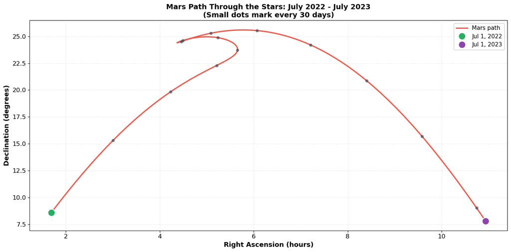

```python
# Handle RA wrap-around at 24h/0h boundary using vectorized operations
# RA is circular: 23h59m → 0h00m, which creates plotting artifacts
# Instead of looping, we use np.diff() to compute all differences at once,
# then use cumulative sum to propagate the 24h shifts
ra_hours = ra_year.hours.copy()
ra_diff = np.diff(ra_hours, prepend=ra_hours[0])

# Identify where wraps occur (jumps > 12h or < -12h)
wrap_up = ra_diff > 12   # Jumped from ~23h to ~0h, need to add 24
wrap_down = ra_diff < -12  # Jumped from ~0h to ~23h, need to subtract 24

# Apply cumulative 24h shifts
shifts = np.cumsum(wrap_up.astype(int) * 24 - wrap_down.astype(int) * 24)
ra_hours = ra_hours + shifts

# Create the plot
plt.figure(figsize=(14, 7))
plt.plot(ra_hours, dec_year.degrees, color='#E74C3C', linewidth=2.5,
         label='Mars path', alpha=0.9)
plt.plot(ra_hours[0], dec_year.degrees[0], 'o', color='#27AE60',
         markersize=14, label='Jul 1, 2022', zorder=5, markeredgecolor='white', markeredgewidth=1.5)
plt.plot(ra_hours[-1], dec_year.degrees[-1], 'o', color='#8E44AD',
         markersize=14, label='Jul 1, 2023', zorder=5, markeredgecolor='white', markeredgewidth=1.5)

# Mark every 30 days with small dots using vectorized indexing
marker_indices = np.arange(0, len(days), 30)
plt.plot(ra_hours[marker_indices], dec_year.degrees[marker_indices], 'o',
         color='#34495E', markersize=5, alpha=0.6)

plt.xlabel('Right Ascension (hours)', fontsize=13, fontweight='bold')
plt.ylabel('Declination (degrees)', fontsize=13, fontweight='bold')
plt.title('Mars Path Through the Stars: July 2022 - July 2023\n(Small dots mark every 30 days)',
          fontsize=14, fontweight='bold')
plt.legend(fontsize=11, loc='best', framealpha=0.95)
plt.grid(alpha=0.3, linestyle=':', color='gray')
plt.tight_layout()
plt.show()
```

Look carefully at the path. Most of the time, Mars moves steadily eastward (increasing RA). But notice something strange - there's a section where the path loops back on itself! This is **retrograde motion**, where Mars appears to reverse direction and move westward temporarily.

This phenomenon puzzled ancient astronomers for millennia. Why would planets sometimes move backwards? The geocentric model with its complex epicycles was partially an attempt to explain this. Copernicus's heliocentric model finally revealed the simple truth: retrograde motion happens when faster-orbiting Earth overtakes slower-orbiting Mars.

Let's analyze this quantitatively to find exactly when retrograde motion occurs.

### Detecting Retrograde Motion

To detect retrograde motion mathematically, we need to find when Mars's Right Ascension stops increasing and starts decreasing. We can approximate the derivative of RA with respect to time by computing the daily change in RA. When this velocity becomes negative, Mars is moving retrograde (westward). When it's positive, Mars is moving prograde (eastward - the normal direction).

We use `np.diff()` to compute the difference between consecutive days, which gives us the velocity in hours of RA per day. We must also handle the RA wrap-around issue here, just as we did for plotting:

```python
# Calculate daily velocity in RA (hours per day)
ra_velocity = np.diff(ra_year.hours)

# Handle RA wrap-around in velocity calculation
ra_velocity[ra_velocity > 12] -= 24
ra_velocity[ra_velocity < -12] += 24

# Classify motion: positive velocity = prograde, negative = retrograde
prograde = ra_velocity > 0
retrograde = ra_velocity < 0

# Find transition points where motion changes direction
# These occur where the sign of velocity changes
transitions = np.where(np.diff(np.sign(ra_velocity)))[0]

print("Mars Motion Analysis:")
print("=" * 70)
print(f"Total days tracked: {len(days)}")
print(f"Days in prograde motion (normal eastward): {np.sum(prograde)}")
print(f"Days in retrograde motion (westward): {np.sum(retrograde)}")
print(f"Transition points found: {len(transitions)}")
```

```
Mars Motion Analysis:
======================================================================
Total days tracked: 396
Days in prograde motion (normal eastward): 320
Days in retrograde motion (westward): 75
Transition points found: 2
```

Now let's identify the exact dates when retrograde motion begins and ends. Typically we find two transitions: the start of retrograde (when Mars begins moving westward) and the end of retrograde (when Mars resumes eastward motion). Let's extract these dates and compute the duration of the retrograde period:

```python
if len(transitions) >= 2:
    retro_start = transitions[0]
    retro_end = transitions[1]

    print(f"\nRetrograde period details:")
    print(f"  Begins: {times_year[retro_start].utc_strftime('%Y-%m-%d')}")
    print(f"  Ends:   {times_year[retro_end].utc_strftime('%Y-%m-%d')}")
    print(f"  Duration: {retro_end - retro_start} days")
    print(f"\nRetrograde occurred between RA {ra_year.hours[retro_start]:.2f}h and {ra_year.hours[retro_end]:.2f}h")
```

```
Retrograde period details:
  Begins: 2022-10-29
  Ends:   2023-01-12
  Duration: 75 days

Retrograde occurred between RA 5.66h and 4.37h
```

### Visualizing Retrograde and Prograde Motion

Now let's create an enhanced visualization that clearly distinguishes between prograde and retrograde motion using color coding. We use array slicing to split the path at the transition indices, plotting prograde segments in blue and the retrograde segment in red. Python's slice notation `array[start:end]` extracts elements from start to end-1, allowing us to connect the segments smoothly:

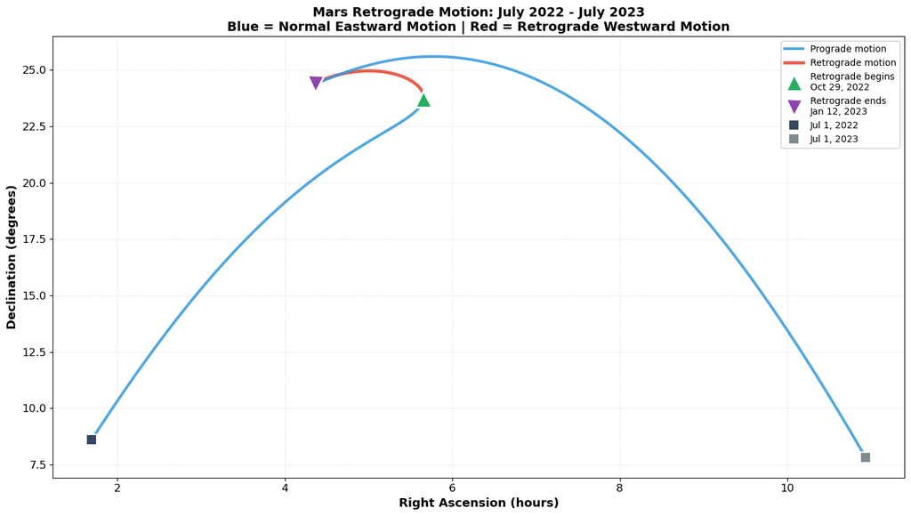

```python
# Handle RA wrap-around for this plot too
ra_hours_retro = ra_year.hours.copy()
for i in range(1, len(ra_hours_retro)):
    diff = ra_hours_retro[i] - ra_hours_retro[i-1]
    if diff > 12:
        ra_hours_retro[i:] += 24
    elif diff < -12:
        ra_hours_retro[i:] -= 24

plt.figure(figsize=(14, 8))

if len(transitions) >= 2:
    retro_start = transitions[0]
    retro_end = transitions[1]

    # Plot prograde motion before retrograde (blue)
    plt.plot(ra_hours_retro[:retro_start+1], dec_year.degrees[:retro_start+1],
             color='#3498DB', linewidth=3, label='Prograde motion', alpha=0.85)

    # Plot retrograde motion (red)
    plt.plot(ra_hours_retro[retro_start:retro_end+1], dec_year.degrees[retro_start:retro_end+1],
             color='#E74C3C', linewidth=3.5, label='Retrograde motion', alpha=0.9)

    # Plot prograde motion after retrograde (blue)
    plt.plot(ra_hours_retro[retro_end:], dec_year.degrees[retro_end:],
             color='#3498DB', linewidth=3, alpha=0.85)

    # Mark transition points
    plt.plot(ra_hours_retro[retro_start], dec_year.degrees[retro_start],
             '^', color='#27AE60', markersize=18,
             label=f'Retrograde begins\n{times_year[retro_start].utc_strftime("%b %d, %Y")}',
             zorder=5, markeredgecolor='white', markeredgewidth=2)
    plt.plot(ra_hours_retro[retro_end], dec_year.degrees[retro_end],
             'v', color='#8E44AD', markersize=18,
             label=f'Retrograde ends\n{times_year[retro_end].utc_strftime("%b %d, %Y")}',
             zorder=5, markeredgecolor='white', markeredgewidth=2)
else:
    plt.plot(ra_hours_retro, dec_year.degrees, color='#3498DB',
             linewidth=3, label='Mars path', alpha=0.85)

# Mark start and end of observation period
plt.plot(ra_hours_retro[0], dec_year.degrees[0], 's', color='#34495E',
         markersize=12, label='Jul 1, 2022', zorder=4,
         markeredgecolor='white', markeredgewidth=1.5)
plt.plot(ra_hours_retro[-1], dec_year.degrees[-1], 's', color='#7F8C8D',
         markersize=12, label='Jul 1, 2023', zorder=4,
         markeredgecolor='white', markeredgewidth=1.5)

plt.xlabel('Right Ascension (hours)', fontsize=13, fontweight='bold')
plt.ylabel('Declination (degrees)', fontsize=13, fontweight='bold')
plt.title("Mars Retrograde Motion: July 2022 - July 2023\nBlue = Normal Eastward Motion | Red = Retrograde Westward Motion",
          fontsize=14, fontweight='bold')
plt.legend(fontsize=10, loc='best', framealpha=0.95)
plt.grid(alpha=0.3, linestyle=':', color='gray')
plt.tight_layout()
plt.show()
```

### Understanding Why Retrograde Happens

Now we can see the retrograde loop clearly. But why does this happen? The answer lies in the geometry of planetary orbits and the relative speeds of Earth and Mars.

Earth orbits the Sun once every 365.25 days at a distance of 1 AU, giving it an orbital velocity of about 30 km/s. Mars orbits once every 687 days at a distance of 1.52 AU, with an orbital velocity of about 24 km/s. Because Earth moves faster and in an inner orbit, it periodically overtakes Mars - roughly every 26 months (the synodic period).

Imagine you're on a racetrack in the inside lane, and a friend is in the outside lane running slower than you. As you approach from behind, your friend appears to move forward relative to the grandstand. But as you pass them, they appear to move backward relative to the grandstand even though they're still running forward. After you pass, they appear to move forward again.

This is exactly what happens with Mars. For most of the year, both Earth and Mars move in the same direction (counterclockwise as viewed from above the North Pole), and Mars appears to move eastward against the background stars. But during the ~60-80 days when Earth is overtaking Mars, Mars appears to move westward. This is an illusion caused by our changing viewing perspective - Mars never actually reverses its orbital direction.

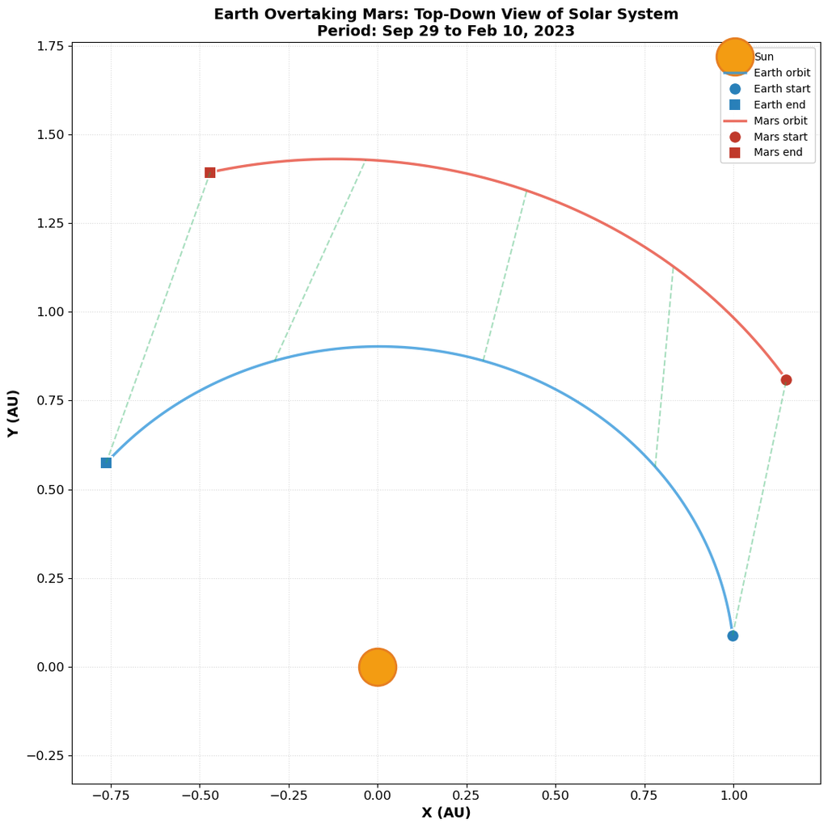

```python
if len(transitions) >= 2:
    # Focus on ±30 days around retrograde for clarity
    start_idx = max(0, retro_start - 30)
    end_idx = min(len(days), retro_end + 30)
    times_retro = times_year[start_idx:end_idx]

    # Get Earth and Mars positions relative to the Sun
    earth_pos = sun.at(times_retro).observe(earth)
    mars_pos = sun.at(times_retro).observe(mars)
    earth_xyz = earth_pos.position.au
    mars_xyz = mars_pos.position.au

    plt.figure(figsize=(11, 11))

    # Plot Sun at center
    plt.plot(0, 0, 'o', color='#F39C12', markersize=35, label='Sun', zorder=5,
             markeredgecolor='#E67E22', markeredgewidth=2)

    # Plot Earth's orbital path
    plt.plot(earth_xyz[0], earth_xyz[1], color='#3498DB', linewidth=2.5,
             label='Earth orbit', alpha=0.8)
    plt.plot(earth_xyz[0, 0], earth_xyz[1, 0], 'o', color='#2980B9',
             markersize=12, label='Earth start', markeredgecolor='white', markeredgewidth=1.5)
    plt.plot(earth_xyz[0, -1], earth_xyz[1, -1], 's', color='#2980B9',
             markersize=12, label='Earth end', markeredgecolor='white', markeredgewidth=1.5)

    # Plot Mars's orbital path
    plt.plot(mars_xyz[0], mars_xyz[1], color='#E74C3C', linewidth=2.5,
             label='Mars orbit', alpha=0.8)
    plt.plot(mars_xyz[0, 0], mars_xyz[1, 0], 'o', color='#C0392B',
             markersize=12, label='Mars start', markeredgecolor='white', markeredgewidth=1.5)
    plt.plot(mars_xyz[0, -1], mars_xyz[1, -1], 's', color='#C0392B',
             markersize=12, label='Mars end', markeredgecolor='white', markeredgewidth=1.5)

    # Draw sight lines at key moments
    key_times = [0, len(times_retro)//4, len(times_retro)//2, 3*len(times_retro)//4, -1]
    for i in key_times:
        plt.plot([earth_xyz[0, i], mars_xyz[0, i]],
                [earth_xyz[1, i], mars_xyz[1, i]],
                color='#27AE60', linestyle='--', alpha=0.4, linewidth=1.5)

    plt.xlabel('X (AU)', fontsize=13, fontweight='bold')
    plt.ylabel('Y (AU)', fontsize=13, fontweight='bold')
    plt.title('Earth Overtaking Mars: Top-Down View of Solar System\n' +
              f'Period: {times_retro[0].utc_strftime("%b %d")} to {times_retro[-1].utc_strftime("%b %d, %Y")}',
              fontsize=14, fontweight='bold')
    plt.legend(fontsize=10, loc='best', framealpha=0.95)
    plt.grid(alpha=0.3, linestyle=':', color='gray')
    plt.axis('equal')
    plt.tight_layout()
    plt.show()
```

This top-down view makes it clear: both planets always move forward (counterclockwise) in their orbits. The apparent backward motion of Mars as seen from Earth is entirely a projection effect. This simple geometric explanation eluded astronomers for thousands of years until Copernicus placed the Sun at the center of the solar system.

Mars undergoes retrograde motion approximately every 26 months (780 days), when Earth laps it in their race around the Sun. The duration of retrograde varies from about 60 to 80 days depending on where in their orbits the two planets are when the overtaking occurs. The retrograde loops are most dramatic when Mars is near opposition (opposite the Sun in Earth's sky), which is also when Mars appears brightest and largest, making it the best time for telescopic observation.

## Planetary Conjunctions

### What Is a Conjunction?

A **conjunction** occurs when two celestial objects appear close together in the sky from our viewpoint on Earth. This doesn't mean they're physically near each other in space - Jupiter and Saturn might be billions of kilometers apart but appear close from Earth's perspective because they happen to lie along nearly the same line of sight. Conjunctions are beautiful to observe because you can see multiple bright objects in the same telescope field of view or even with the naked eye.

**Defining "conjunction" precisely:** In practice, astronomers use different conventions:

- **Minimum angular separation**: The simplest definition - when two objects reach their smallest great-circle separation on the celestial sphere (what we'll use in this lecture)
- **Equal ecliptic longitude**: Traditional astronomical definition - when both objects have the same ecliptic longitude (the ecliptic is the plane of Earth's orbit around the Sun, which defines a fundamental reference plane in the sky)
- **Equal right ascension**: When both objects cross the same meridian (same RA)

These three definitions can give slightly different dates for the "exact" conjunction, usually within a day of each other. For observation planning, the minimum separation approach is most practical because it tells you when the objects look closest together.

There are several types of conjunctions:

- **Planetary conjunctions** occur when two planets appear close together, which happens when their orbital paths cross in our sky
- **Lunar conjunctions** happen when the Moon passes near a planet or bright star during its monthly journey around the sky
- **Occultations** are special cases where the Moon actually passes in front of and blocks another object

Conjunctions have fascinated humans throughout history. Ancient astrologers considered them portentous events. Modern astronomers use them for practical purposes: you can observe two objects in one observing session, compare their colors and brightness side-by-side, and photograph them together for beautiful images. The famous "Star of Bethlehem" may have been a conjunction of Jupiter and Saturn in 7 BCE.

Let's use SkyField to find actual conjunctions between Mars and Jupiter over the next 18 months. We'll search systematically and identify all close approaches.

### Finding Mars-Jupiter Conjunctions

To find conjunctions, we need to compute the angular separation between Mars and Jupiter at many times and look for minima (the points where they're closest together). We'll search from October 2025 through March 2027 (18 months) to ensure we catch any conjunctions that occur during this period.

The strategy is to compute positions every day, calculate the angular separation using the `.separation_from()` method, and find when that separation reaches local minima. Let's start by computing the separation at daily intervals:

```python
# Define search period: October 2025 through March 2027 (18 months)
search_days = np.arange(0, 18*30)  # Approximately 18 months
times_search = ts.utc(2025, 10, 1 + search_days)

print(f"Searching for Mars-Jupiter conjunctions...")
print(f"Period: {times_search[0].utc_strftime('%Y-%m-%d')} to {times_search[-1].utc_strftime('%Y-%m-%d')}")
print(f"Computing separations at {len(times_search)} daily intervals...")
```

```
Searching for Mars-Jupiter conjunctions...
Period: 2025-10-01 to 2027-03-24
Computing separations at 540 daily intervals...
```

Now we'll compute the apparent positions (including aberration) of both planets and calculate their angular separation for each day. The `.separation_from()` method computes great-circle distance on the celestial sphere, accounting for spherical geometry. SkyField's vectorized operations allow us to compute all 540+ separations at once, which is much faster than looping:

```python
# Calculate angular separations using vectorized operations
# Modern approach: compute all positions at once, then calculate separations
# This is much faster than looping through individual times
mars_positions = earth.at(times_search).observe(mars).apparent()
jupiter_positions = earth.at(times_search).observe(jupiter).apparent()

# Calculate all separations at once
separations = mars_positions.separation_from(jupiter_positions).degrees

print(f"\nSeparation analysis:")
print(f"  Minimum: {np.min(separations):.2f}°")
print(f"  Maximum: {np.max(separations):.2f}°")
print(f"  Mean: {np.mean(separations):.2f}°")
```

```
Separation analysis:
  Minimum: 1.19°
  Maximum: 179.22°
  Mean: 71.39°
```

```python
# Find all close approaches (< 10 degrees)
close_threshold = 10.0  # degrees
close_approaches = np.where(separations < close_threshold)[0]

if len(close_approaches) > 0:
    print(f"\nFound {len(close_approaches)} days when Mars and Jupiter are within {close_threshold}°")

    # Find local minima (actual conjunctions) using vectorized comparison
    # A local minimum occurs where: sep[i] < sep[i-1] AND sep[i] < sep[i+1]
    # We use np.diff to find where the separation stops decreasing and starts increasing
    sep_diff = np.diff(separations)

    # Local minima occur where the derivative changes from negative to positive
    is_local_min = (sep_diff[:-1] < 0) & (sep_diff[1:] > 0)

    # Add 1 to indices because diff reduces array length
    potential_conjunctions = np.where(is_local_min)[0] + 1

    # Filter to only those below our threshold
    conjunctions = potential_conjunctions[separations[potential_conjunctions] < close_threshold]

    print(f"\nIdentified {len(conjunctions)} conjunction(s):\n")
    print("Date                Separation    Comment")
    print("=" * 65)

    for idx in conjunctions:
        date_str = times_search[idx].utc_strftime('%Y-%m-%d')
        sep = separations[idx]

        if sep < 2:
            comment = "Very close! Visible in telescope field"
        elif sep < 5:
            comment = "Close! Visible together in binoculars"
        elif sep < 10:
            comment = "Moderately close, wide field view"
        else:
            comment = ""

        print(f"{date_str:20s}{sep:6.2f}°        {comment}")

    # Find and highlight the closest approach
    closest_idx = np.argmin(separations)
    closest_date = times_search[closest_idx].utc_strftime('%Y-%m-%d')
    closest_sep = separations[closest_idx]

    print("\n" + "=" * 65)
    print(f"CLOSEST APPROACH: {closest_date}")
    print(f"Separation: {closest_sep:.3f}° ({closest_sep * 60:.1f} arcminutes)")
    print(f"For reference: Moon diameter is ~0.5° (30 arcminutes)")
else:
    print(f"\nNo close approaches found (all separations > {close_threshold}°)")
```

```
Found 88 days when Mars and Jupiter are within 10.0°

Identified 1 conjunction(s):

Date                Separation    Comment
=================================================================
2026-11-16            1.19°        Very close! Visible in telescope field

=================================================================
CLOSEST APPROACH: 2026-11-16
Separation: 1.194° (71.6 arcminutes)
For reference: Moon diameter is ~0.5° (30 arcminutes)
```

### Visualizing the Separation Over Time

Now let's visualize how the separation changes over the entire 18-month period. This helps us understand when the conjunction is approaching, how long the planets remain close, and when they separate again. We'll also add reference lines showing typical binocular and telescope field of view sizes:

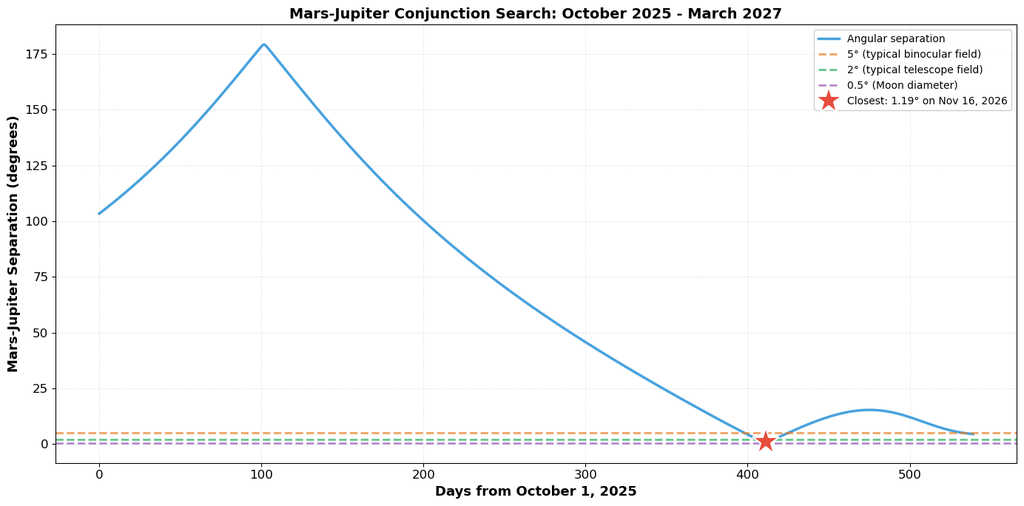

```python
plt.figure(figsize=(14, 7))

# Plot separation over time
plt.plot(search_days, separations, color='#3498DB', linewidth=2.5,
         label='Angular separation', alpha=0.9)

# Add reference lines for field of view sizes
plt.axhline(5, color='#E67E22', linestyle='--', alpha=0.7, linewidth=2,
            label='5° (typical binocular field)')
plt.axhline(2, color='#27AE60', linestyle='--', alpha=0.7, linewidth=2,
            label='2° (typical telescope field)')
plt.axhline(0.5, color='#9B59B6', linestyle='--', alpha=0.7, linewidth=2,
            label='0.5° (Moon diameter)')

# Mark the closest approach
closest_idx = np.argmin(separations)
plt.plot(search_days[closest_idx], separations[closest_idx], '*',
         color='#E74C3C', markersize=28,
         label=f'Closest: {separations[closest_idx]:.2f}° on {times_search[closest_idx].utc_strftime("%b %d, %Y")}',
         markeredgecolor='white', markeredgewidth=1.5, zorder=5)

plt.xlabel('Days from October 1, 2025', fontsize=13, fontweight='bold')
plt.ylabel('Mars-Jupiter Separation (degrees)', fontsize=13, fontweight='bold')
plt.title('Mars-Jupiter Conjunction Search: October 2025 - March 2027',
          fontsize=14, fontweight='bold')
plt.legend(fontsize=10, loc='best', framealpha=0.95)
plt.grid(alpha=0.3, linestyle=':', color='gray')
plt.tight_layout()
plt.show()
```

### Understanding the Conjunction in Detail

Let's focus on the period around the closest approach to see how Mars and Jupiter's positions evolve. We'll look at ±30 days around the closest approach and track both planets' paths across the sky. This will show us how their paths converge, how close they actually get, and how they then separate again.

We'll create a sky chart showing the actual celestial coordinates (RA and Dec) of both planets, marking their positions every 5 days to show their relative speeds of motion:

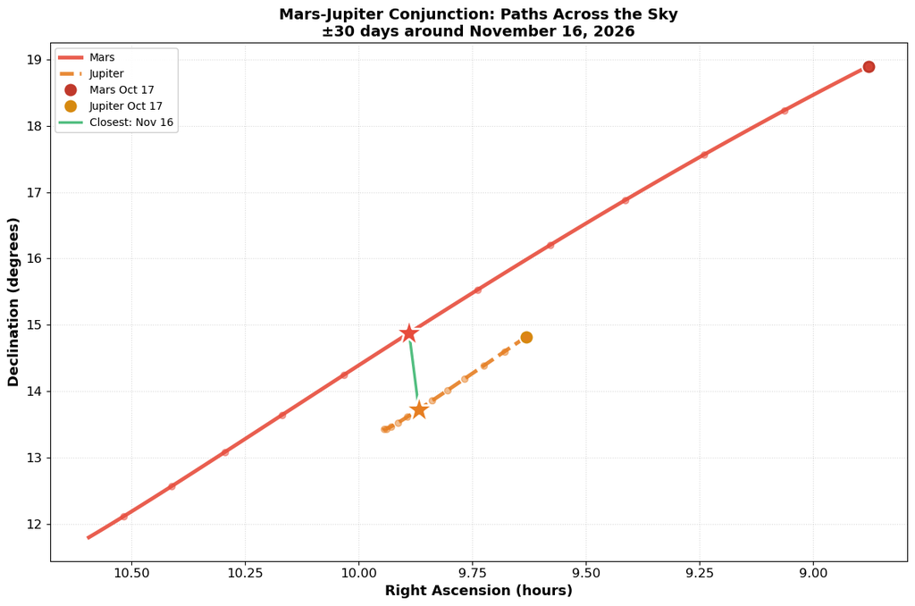

```python
# Focus on ±30 days around closest approach
closest_idx = np.argmin(separations)
closest_day = search_days[closest_idx]

# Create detailed daily times around conjunction
detail_days = np.arange(max(0, closest_day - 30), min(len(search_days), closest_day + 30))
times_detail = ts.utc(2025, 10, 1 + detail_days)

# Get positions for detailed period
mars_detail = earth.at(times_detail).observe(mars).apparent()
jupiter_detail = earth.at(times_detail).observe(jupiter).apparent()
mars_ra_det, mars_dec_det, _ = mars_detail.radec()
jupiter_ra_det, jupiter_dec_det, _ = jupiter_detail.radec()

plt.figure(figsize=(12, 8))

# Plot both planets' paths
plt.plot(mars_ra_det.hours, mars_dec_det.degrees, color='#E74C3C', linewidth=3.5,
         label='Mars', alpha=0.9)
plt.plot(jupiter_ra_det.hours, jupiter_dec_det.degrees, color='#E67E22', linewidth=3.5,
         label='Jupiter', alpha=0.9, linestyle='--')

# Mark start positions
plt.plot(mars_ra_det.hours[0], mars_dec_det.degrees[0], 'o', color='#C0392B',
         markersize=13, label=f'Mars {times_detail[0].utc_strftime("%b %d")}',
         markeredgecolor='white', markeredgewidth=1.5)
plt.plot(jupiter_ra_det.hours[0], jupiter_dec_det.degrees[0], 'o', color='#D68910',
         markersize=13, label=f'Jupiter {times_detail[0].utc_strftime("%b %d")}',
         markeredgecolor='white', markeredgewidth=1.5)

# Mark closest approach
closest_in_detail = np.argmin(np.abs(detail_days - closest_day))
plt.plot(mars_ra_det.hours[closest_in_detail], mars_dec_det.degrees[closest_in_detail],
         '*', color='#E74C3C', markersize=28, zorder=5,
         markeredgecolor='white', markeredgewidth=2)
plt.plot(jupiter_ra_det.hours[closest_in_detail], jupiter_dec_det.degrees[closest_in_detail],
         '*', color='#E67E22', markersize=28, zorder=5,
         markeredgecolor='white', markeredgewidth=2)

# Draw a line connecting them at closest approach
plt.plot([mars_ra_det.hours[closest_in_detail], jupiter_ra_det.hours[closest_in_detail]],
         [mars_dec_det.degrees[closest_in_detail], jupiter_dec_det.degrees[closest_in_detail]],
         color='#27AE60', linewidth=2.5, alpha=0.8,
         label=f'Closest: {times_detail[closest_in_detail].utc_strftime("%b %d")}')

# Mark every 5 days with small dots
for i in range(0, len(detail_days), 5):
    plt.plot(mars_ra_det.hours[i], mars_dec_det.degrees[i], 'o',
             color='#E74C3C', markersize=6, alpha=0.5)
    plt.plot(jupiter_ra_det.hours[i], jupiter_dec_det.degrees[i], 'o',
             color='#E67E22', markersize=6, alpha=0.5)

plt.xlabel('Right Ascension (hours)', fontsize=13, fontweight='bold')
plt.ylabel('Declination (degrees)', fontsize=13, fontweight='bold')
plt.title(f'Mars-Jupiter Conjunction: Paths Across the Sky\n±30 days around {times_search[closest_idx].utc_strftime("%B %d, %Y")}',
          fontsize=14, fontweight='bold')
plt.legend(fontsize=10, loc='best', framealpha=0.95)
plt.grid(alpha=0.3, linestyle=':', color='gray')
plt.gca().invert_xaxis()  # RA increases right to left by convention
plt.tight_layout()
plt.show()
```

This visualization reveals the orbital mechanics behind conjunctions. Mars, being closer to the Sun, has a shorter orbital period (687 days vs 4,333 days for Jupiter) and thus appears to move faster across the sky relative to the background stars. Eventually Mars catches up to and passes Jupiter from our Earth-based viewpoint, creating the conjunction.

From Earth's perspective, we're watching a complex dance orchestrated by the gravitational clockwork of the solar system. The planets themselves follow their elliptical orbits governed by Kepler's laws, but the apparent motion we see from Earth is a projection effect that combines our own motion with theirs. This is why planetary positions can only be accurately predicted using numerical integration of all the gravitational interactions - the simple two-body problem has given way to the complex choreography of multiple bodies influencing each other.

## Topocentric Coordinates: Your Local Sky

### Geocentric vs Topocentric

So far we've computed positions as seen from Earth's center, which astronomers call **geocentric**. But you're not at Earth's center - you're on the surface at a specific latitude, longitude, and elevation. For planets, this difference barely matters because they're so far away. But for the Moon, only 380,000 kilometers distant, your surface location shifts the apparent position by up to a degree.

**Topocentric** means "as seen from a specific place on Earth's surface." This is what you actually observe when you look through your telescope. The difference arises because Earth's radius is 6,371 kilometers - not negligible compared to the Moon's distance. For Mars at its closest (about 55 million kilometers away), the parallax shift is less than an arcsecond and can be ignored for most amateur work. But for precision astrometry, spacecraft navigation, and lunar observations, topocentric coordinates are essential.

### Understanding WGS84

To specify a location on Earth's surface, we'll use **WGS84** (World Geodetic System 1984), which is the standard coordinate system used by GPS and most modern mapping applications. It's a mathematical model that describes Earth's shape as an ellipsoid (a slightly flattened sphere).

Why do we need this? Earth isn't a perfect sphere - it bulges at the equator due to rotation. The distance from Earth's center to sea level is about 21 km greater at the equator than at the poles. WGS84 provides the precise ellipsoid parameters (equatorial radius = 6378.137 km, flattening = 1/298.257) needed to convert latitude, longitude, and elevation into accurate 3D Cartesian coordinates.

When we write `wgs84.latlon(latitude, longitude, elevation_m=height)`, SkyField uses the WGS84 ellipsoid to compute your exact position in space. This matters for precision astronomy: a 21 km error in your position would cause arcsecond-level errors in object positions, which is significant for applications like asteroid tracking or spacecraft navigation.

Other coordinate systems exist (NAD83 for North America, ITRF for tectonic plate motion studies), but WGS84 is the global standard and is what SkyField uses by default.

Let's define our observing location. We'll continue using Columbus, Ohio as our example, just as we did in Lecture 14. We need to create TWO observer objects due to a quirk in SkyField's API:

1. The first (`columbus`) is for `.observe()` calls and represents Earth's center plus an offset to the surface
2. The second (`columbus_topos`) is for almanac functions and represents just the geographic location

```python
# Define Columbus, Ohio (same coordinates as Lecture 14)
columbus_lat = 39.9612   # degrees North
columbus_lon = -83.0003  # degrees East (negative = West)
columbus_elev = 260      # meters above sea level

# Create topocentric observer for .observe() calls
columbus = earth + wgs84.latlon(columbus_lat, columbus_lon, elevation_m=columbus_elev)

# Create separate Topos object for almanac functions
columbus_topos = wgs84.latlon(columbus_lat, columbus_lon, elevation_m=columbus_elev)

print(f"Observer location defined: Columbus, Ohio")
print(f"  Latitude:  {columbus_lat}° N")
print(f"  Longitude: {columbus_lon}° (West)")
print(f"  Elevation: {columbus_elev} m above sea level")
```

```
Observer location defined: Columbus, Ohio
  Latitude:  39.9612° N
  Longitude: -83.0003° (West)
  Elevation: 260 m above sea level
```

### Computing Altitude and Azimuth

Now we can compute where Mars appears in Columbus's local sky. Just as we did in Lecture 14 with Astropy's AltAz frame, we want Altitude (angle above horizon) and Azimuth (compass direction). The `.altaz()` method returns these coordinates along with distance, and accepts `temperature_C` and `pressure_mbar` parameters to compute atmospheric refraction corrections:

```python
# Observe Mars from Columbus at our time
topocentric = columbus.at(t).observe(mars)
apparent = topocentric.apparent()

# Get altitude and azimuth with refraction
# Temperature and pressure for typical Columbus October conditions
alt, az, distance = apparent.altaz(temperature_C=10.0, pressure_mbar=1010.0)

print(f"Mars from Columbus at {t.utc_iso()}:")
print(f"  Altitude: {alt.degrees:.2f}° (includes atmospheric refraction)")
print(f"  Azimuth:  {az.degrees:.2f}° (0°=N, 90°=E, 180°=S, 270°=W)")
print(f"  Distance: {distance.au:.4f} AU")
```

```
Mars from Columbus at 2025-10-20T02:00:00Z:
  Altitude: -25.90° (includes atmospheric refraction)
  Azimuth:  267.98° (0°=N, 90°=E, 180°=S, 270°=W)
  Distance: 2.3938 AU
```

### Understanding Atmospheric Refraction

The `.altaz()` method requires `.apparent()` because it can apply refraction corrections. Refraction depends on temperature and pressure because these affect air density and thus the refractive index. At the horizon, refraction lifts objects by ~34 arcminutes (about 0.6°). This is why you can see the Sun or Moon even when it's geometrically below the horizon! At 45° altitude, refraction is ~1 arcminute. At zenith (90°), there's no refraction because light travels straight down through the atmosphere.

**Critical:** SkyField only applies refraction when you provide `pressure_mbar > 0`. If you don't specify temperature and pressure, SkyField uses **default values of 10°C and 1010 mbar** for standard atmospheric refraction. However, it's best practice to always be explicit - use `altaz(temperature_C=10.0, pressure_mbar=1010.0)` for realistic observing conditions, or `altaz(temperature_C=0, pressure_mbar=0)` for geometric altitude without refraction.

Let's assess the observing quality based on this altitude. We'll calculate airmass using the secant approximation (1/cos of zenith angle), which tells us how much atmosphere we're looking through:

```python
# Assess observing conditions
if alt.degrees > 0:
    print(f"\n✓ Mars is VISIBLE above the horizon")

    # Calculate airmass using sec(zenith angle) approximation
    zenith_angle = 90 - alt.degrees
    airmass = 1.0 / np.cos(np.radians(zenith_angle))

    if alt.degrees > 60:
        quality = "EXCELLENT (airmass < 1.2)"
    elif alt.degrees > 30:
        quality = "GOOD (airmass < 2)"
    elif alt.degrees > 20:
        quality = "FAIR (airmass < 3)"
    else:
        quality = "POOR (airmass > 3, high extinction)"

    print(f"Observing quality: {quality}")
    print(f"Airmass: {airmass:.2f}")
else:
    print(f"\n✗ Mars is below the horizon")
    print(f"Cannot observe - Mars is {abs(alt.degrees):.1f}° below horizon")
```

```
✗ Mars is below the horizon
Cannot observe - Mars is 25.9° below horizon
```

Remember from Lecture 14 that higher altitude means less atmospheric extinction (less light absorbed), less airmass (less atmosphere to look through), and less turbulence (better seeing). The airmass rules of thumb are: altitude > 60° gives airmass < 1.2 (excellent for photometry and spectroscopy), altitude > 30° gives airmass < 2 (good for most observations), and altitude < 30° gives airmass > 2 (challenging, significant extinction corrections needed).

### Lunar Parallax: When Surface Location Matters

For planets, the difference between geocentric and topocentric positions is tiny - typically milliarcseconds. But for the Moon, your surface location matters significantly. Let's compare by computing the Moon's position both from Earth's center and from Columbus's surface:

```python
# Moon from Earth's center (geocentric)
geocentric_moon = earth.at(t).observe(moon)
geo_ra, geo_dec, geo_dist = geocentric_moon.radec()

# Moon from Columbus surface (topocentric)
topocentric_moon = columbus.at(t).observe(moon)
topo_ra, topo_dec, topo_dist = topocentric_moon.radec()

print(f"Moon position comparison:")
print(f"  Geocentric:  RA={geo_ra}, Dec={geo_dec}")
print(f"  Topocentric: RA={topo_ra}, Dec={topo_dec}")
```

```
Moon position comparison:
  Geocentric:  RA=12h 36m 23.26s, Dec=-06deg 08' 16.8"
  Topocentric: RA=12h 34m 50.72s, Dec=-06deg 38' 47.8"
```

Now let's quantify the parallax shift. The correct way to find angular distance between two positions is using great-circle separation with `.separation_from()` - this accounts for spherical geometry properly:

```python
# Calculate parallax using great-circle separation
parallax_angle = geocentric_moon.separation_from(topocentric_moon)

print(f"\nLunar parallax caused by observer location:")
print(f"  Angular separation: {parallax_angle.degrees:.4f}°")
print(f"  Angular separation: {parallax_angle.degrees * 3600:.1f} arcseconds")
print(f"  Angular separation: {parallax_angle.degrees * 60:.2f} arcminutes")
print(f"\nFor reference:")
print(f"  Moon's angular diameter: ~1800 arcseconds (30 arcminutes, 0.5°)")
print(f"  Jupiter's angular diameter: ~45 arcseconds at opposition")

moon_diameter_arcsec = 1800
parallax_arcsec = parallax_angle.degrees * 3600

print(f"\nThis parallax is {parallax_arcsec / moon_diameter_arcsec * 100:.1f}% of the Moon's diameter")
```

```
Lunar parallax caused by observer location:
  Angular separation: 0.6368°
  Angular separation: 2292.4 arcseconds
  Angular separation: 38.21 arcminutes

For reference:
  Moon's angular diameter: ~1800 arcseconds (30 arcminutes, 0.5°)
  Jupiter's angular diameter: ~45 arcseconds at opposition

This parallax is 127.4% of the Moon's diameter
```

The lunar parallax can be several thousand arcseconds depending on the Moon's position in the sky. When the Moon is on the horizon, the parallax is maximum because you're offset perpendicular to the line of sight. When the Moon is overhead (at zenith), the parallax is minimum. This is why eclipse timing varies by location - observers in different locations see the Moon shifted by different amounts relative to the Sun. For precision lunar work, such as lunar occultation timing, topocentric coordinates are absolutely essential. For planets, parallax is measured in milliarcseconds, which we can safely ignore for observation planning but matters for spacecraft navigation.

## Rise, Set, and Transit Times

### What Is an Almanac?

In astronomy, an **almanac** is a collection of tables predicting celestial events. Before computers, astronomers relied on printed almanacs like *The Astronomical Almanac*, published annually by the U.S. Naval Observatory and Her Majesty's Nautical Almanac Office. These massive volumes contained thousands of pages of tables giving sunrise and sunset times for every day of the year at various latitudes, moonrise and moonset, planetary positions at daily intervals, eclipse predictions including visibility maps, and much more.

Creating these almanacs required enormous computational effort. Teams of human "computers" (that was a job title!) performed calculations by hand or with mechanical calculating machines. The introduction of electronic computers revolutionized this work in the 1960s and 1970s. Now we can compute almanac information on demand for any location and time.

SkyField's `almanac` module provides functions to find when objects rise above the horizon, when they set below the horizon, when they transit (cross the meridian at highest altitude), when twilight begins and ends at various levels, when eclipses occur, and when planetary phenomena like conjunctions happen.

### Finding Mars Rise and Set Times

When does Mars rise and set from Columbus over the next few days? This tells us when the planet is potentially observable.

We'll use `almanac.risings_and_settings()` which returns a function that we then pass to `almanac.find_discrete()`. The `horizon_degrees=-0.566` is critical - it accounts for atmospheric refraction, which makes objects appear higher than their true geometric position:

```python
# Define time range: October 20-23, 2025 (just 3 days)
t0 = ts.utc(2025, 10, 20)
t1 = ts.utc(2025, 10, 23)

# Create rise/set function for Mars from Columbus
# horizon_degrees=-0.566 accounts for standard atmospheric refraction
f = almanac.risings_and_settings(eph, mars, columbus_topos, horizon_degrees=-0.566)
times, events = almanac.find_discrete(t0, t1, f)

print("Mars Rise/Set Times from Columbus (Oct 20-23, 2025):")
print("=" * 70)
for ti, event in zip(times, events):
    event_type = 'rises above horizon' if event else 'sets below horizon'
    print(f"  {ti.utc_strftime('%Y-%m-%d %H:%M UTC')} - Mars {event_type}")
```

```
Mars Rise/Set Times from Columbus (Oct 20-23, 2025):
======================================================================
  2025-10-20 13:42 UTC - Mars rises above horizon
  2025-10-20 23:42 UTC - Mars sets below horizon
  2025-10-21 13:41 UTC - Mars rises above horizon
  2025-10-21 23:40 UTC - Mars sets below horizon
  2025-10-22 13:41 UTC - Mars rises above horizon
  2025-10-22 23:38 UTC - Mars sets below horizon
```

### Understanding Transit

**Transit** or **meridian crossing** is when an object crosses your local meridian, the imaginary line running from north through zenith (straight overhead) to south. This is one of the most important times for astronomical observation, and understanding it is crucial for planning high-quality observations.

#### Why Transit Matters

At transit, three important things happen simultaneously. First, the object reaches its **maximum altitude** - its highest point above the horizon for that day. This is as close to straight overhead as that object will get from your location.

Second, you get **optimal atmospheric conditions**. At transit, you're looking through the **minimum airmass** - the least amount of atmosphere. Airmass at zenith is 1.0, but at 30° altitude it's 2.0 (twice as much air). This minimum airmass means **least atmospheric extinction** - less atmosphere means less light absorption. For faint objects, this can mean the difference between detection and non-detection. You also get the **best seeing** because atmospheric turbulence has less distance to distort the image. High-resolution imaging (planetary photography, lunar details, binary star separation) is best done near transit. Finally, you experience **minimal atmospheric dispersion** - the atmosphere acts like a prism, spreading light into colors. This effect is strongest near the horizon and minimal at transit, making it ideal for spectroscopy and precise astrometry.

Third, the object has a **predictable azimuth**. From northern hemisphere locations, most objects transit due south (azimuth = 180°). Circumpolar objects transit due north (azimuth = 0° or 360°). This makes telescope pointing and tracking straightforward.

#### The Meridian Line

The **meridian** is the great circle that runs from due north (azimuth 0°), through your zenith (straight up), to due south (azimuth 180°), and continues below the horizon. Every celestial object crosses your meridian twice per day. The **upper transit** occurs when it crosses while above the horizon - this is the useful one for observations. The **lower transit** occurs when it crosses while below the horizon and is not observable.

For stars, transit occurs about 4 minutes earlier each day due to Earth's orbit around the Sun. For the Sun itself, transit defines **local solar noon** - when the Sun is highest in your sky.

Let's find Mars's transit times using `almanac.meridian_transits()`. For each transit, we'll also compute the altitude at that moment to see how high Mars gets:

```python
# Find Mars transits (meridian crossings)
f_transit = almanac.meridian_transits(eph, mars, columbus_topos)
times_transit, _ = almanac.find_discrete(t0, t1, f_transit)

print("\nMars Transit Times (highest altitude each day):")
print("=" * 70)
for ti in times_transit[:2]:  # Show just first 2
    topo = columbus.at(ti).observe(mars).apparent()
    alt, az, _ = topo.altaz(temperature_C=10.0, pressure_mbar=1010.0)
    print(f"  {ti.utc_strftime('%Y-%m-%d %H:%M UTC')}")
    print(f"    Max altitude: {alt.degrees:.2f}°, Azimuth: {az.degrees:.2f}°\n")
```

```
Mars Transit Times (highest altitude each day):
======================================================================
  2025-10-20 06:43 UTC
    Max altitude: -67.83°, Azimuth: 0.00°

  2025-10-20 18:42 UTC
    Max altitude: 32.18°, Azimuth: 180.00°
```

## The Sun: Defining Day and Night

### Sunrise and Sunset

The most fundamental almanac calculation is determining when the Sun rises and sets. This defines when astronomical observations are possible, when we need telescope dome lights and red flashlights, and when we can safely open telescope domes without daylight damaging equipment.

The `almanac.sunrise_sunset()` function automatically uses the correct horizon value for the Sun (-0.833°, which is different from planets because the Sun has a larger angular diameter of 0.5° and we define sunrise/sunset as when the upper limb touches the horizon, not the center):

```python
# Find sunrise/sunset for three days
f_sun = almanac.sunrise_sunset(eph, columbus_topos)
times_sun, events_sun = almanac.find_discrete(t0, t1, f_sun)

print("Sunrise/Sunset in Columbus (Oct 20-23, 2025):")
print("=" * 70)
for ti, event in zip(times_sun[:6], events_sun[:6]):  # First 6 events
    event_type = 'Sunrise ☀️' if event else 'Sunset 🌅'
    print(f"  {ti.utc_strftime('%Y-%m-%d %H:%M UTC')} - {event_type}")
```

```
Sunrise/Sunset in Columbus (Oct 20-23, 2025):
======================================================================
  2025-10-20 11:48 UTC - Sunrise ☀️
  2025-10-20 22:45 UTC - Sunset 🌅
  2025-10-21 11:49 UTC - Sunrise ☀️
  2025-10-21 22:43 UTC - Sunset 🌅
  2025-10-22 11:50 UTC - Sunrise ☀️
  2025-10-22 22:42 UTC - Sunset 🌅
```

### Twilight: The Transition Between Day and Night

Remember from Lecture 14 that sunset doesn't mean immediate darkness. The Sun continues illuminating the upper atmosphere, keeping the sky bright during **twilight**. There are three twilight phases based on how far the Sun is below the horizon:

**Civil twilight** (Sun 0° to -6°): There's enough natural light for outdoor activities without artificial light. You can read a book outdoors. Only the brightest planets and stars are visible. The brightest part of the sky is still blue. This is "dusk" or "dawn."

**Nautical twilight** (Sun -6° to -12°): The sky is darker, but the horizon is still visible at sea (hence "nautical"). Bright stars are visible and useful for navigation. The sky background is still too bright for faint object observations.

**Astronomical twilight** (Sun -12° to -18°): The sky appears dark to the naked eye and most stars are visible. However, sensitive astronomical observations can still detect scattered sunlight.

**Astronomical night** (Sun below -18°): The sky is truly dark with minimal scattered sunlight. This is when you can observe the faintest objects like distant galaxies, faint nebulae, and do precision photometry and spectroscopy. The Milky Way is clearly visible from dark sites.

For bright objects like planets, you might tolerate nautical or even civil twilight. But for faint science targets requiring CCD imaging or precision photometry, you need true night. Let's compute the twilight transitions:

```python
# Find twilight/darkness transitions
# Returns codes: 0=dark, 1=astronomical, 2=nautical, 3=civil, 4=day
f_dark = almanac.dark_twilight_day(eph, columbus_topos)
times_dark, phases = almanac.find_discrete(t0, t1, f_dark)

phase_names = {
    0: 'Dark Night (Sun < -18°)',
    1: 'Astronomical Twilight (Sun -18° to -12°)',
    2: 'Nautical Twilight (Sun -12° to -6°)',
    3: 'Civil Twilight (Sun -6° to 0°)',
    4: 'Day (Sun > 0°)'
}

print("\nTwilight Transitions (first 6 events):")
print("=" * 70)
for ti, phase in zip(times_dark[:6], phases[:6]):
    print(f"  {ti.utc_strftime('%Y-%m-%d %H:%M UTC')}")
    print(f"    Entering: {phase_names[phase]}\n")
```

```
Twilight Transitions (first 6 events):
======================================================================
  2025-10-20 00:16 UTC
    Entering: Dark Night (Sun < -18°)

  2025-10-20 10:18 UTC
    Entering: Astronomical Twilight (Sun -18° to -12°)

  2025-10-20 10:49 UTC
    Entering: Nautical Twilight (Sun -12° to -6°)

  2025-10-20 11:21 UTC
    Entering: Civil Twilight (Sun -6° to 0°)

  2025-10-20 11:48 UTC
    Entering: Day (Sun > 0°)

  2025-10-20 22:45 UTC
    Entering: Civil Twilight (Sun -6° to 0°)
```

This shows the progression through twilight phases. Around sunset, you transition from Day (4) to Civil (3) to Nautical (2) to Astronomical (1) twilight, finally reaching true Dark (0) when the Sun is below -18°. The sequence reverses before sunrise. The timing varies by latitude and season - near the summer solstice at high latitudes, astronomical twilight may last all night (or the Sun may never set at all above the Arctic Circle).

## The Moon: Phases and Visibility

### Understanding Lunar Phases

The Moon's appearance changes throughout its orbit because we see different amounts of its sunlit hemisphere. This happens because the Moon orbits Earth while the Sun illuminates it from a fixed direction. As the Moon moves around Earth, the angle between the Sun, Moon, and Earth changes, causing us to see different amounts of the illuminated side.

At **new moon**, the Moon is between Earth and Sun, with its dark side facing us - it's essentially invisible. At **first quarter**, about one week later, the Moon is 90° east of the Sun. We see the right half illuminated, and the Moon is visible in the afternoon and evening, setting around midnight. At **full moon**, about two weeks after new moon, the Moon is opposite the Sun. We see the entire sunlit hemisphere, and it rises at sunset and sets at sunrise, visible all night. At **last quarter**, about three weeks after new moon, the Moon is 90° west of the Sun. We see the left half illuminated, and it's visible in the late night and morning.

These phases repeat every 29.5 days, called the **synodic month** (the time from new moon to new moon). This is slightly longer than the Moon's orbital period of 27.3 days (the sidereal month) because Earth is also orbiting the Sun, so the Moon must travel a bit extra to get back to the same position relative to the Sun and Earth.

The Moon's phases matter enormously for observing. A full Moon at magnitude -12.6 is bright enough to wash out faint objects, increase sky background significantly, and make some faint star fields invisible. The 10-day period around new moon (±5 days) is called "dark time" and is highly prized for faint object observations. Let's find when lunar phases occur:

```python
# Find moon phases over next 6 months
t0_phases = ts.utc(2025, 10, 20)
t1_phases = ts.utc(2026, 4, 20)
f_moon = almanac.moon_phases(eph)
times_phases, phases = almanac.find_discrete(t0_phases, t1_phases, f_moon)

phase_names = ['🌑 New Moon', '🌓 First Quarter', '🌕 Full Moon', '🌗 Last Quarter']

print("Lunar Phases (Oct 2025 - Apr 2026):")
print("=" * 70)
for ti, phase in zip(times_phases, phases):
    print(f"  {ti.utc_strftime('%Y-%m-%d %H:%M UTC')} - {phase_names[phase]}")
```

```
Lunar Phases (Oct 2025 - Apr 2026):
======================================================================
  2025-10-21 12:25 UTC - 🌑 New Moon
  2025-10-29 16:21 UTC - 🌓 First Quarter
  2025-11-05 13:19 UTC - 🌕 Full Moon
  2025-11-12 05:28 UTC - 🌗 Last Quarter
  2025-11-20 06:47 UTC - 🌑 New Moon
  2025-11-28 06:59 UTC - 🌓 First Quarter
  2025-12-04 23:14 UTC - 🌕 Full Moon
  2025-12-11 20:52 UTC - 🌗 Last Quarter
  2025-12-20 01:43 UTC - 🌑 New Moon
  2025-12-27 19:10 UTC - 🌓 First Quarter
  2026-01-03 10:03 UTC - 🌕 Full Moon
  2026-01-10 15:48 UTC - 🌗 Last Quarter
  2026-01-18 19:52 UTC - 🌑 New Moon
  2026-01-26 04:47 UTC - 🌓 First Quarter
  2026-02-01 22:09 UTC - 🌕 Full Moon
  2026-02-09 12:43 UTC - 🌗 Last Quarter
  2026-02-17 12:01 UTC - 🌑 New Moon
  2026-02-24 12:28 UTC - 🌓 First Quarter
  2026-03-03 11:38 UTC - 🌕 Full Moon
  2026-03-11 09:39 UTC - 🌗 Last Quarter
  2026-03-19 01:23 UTC - 🌑 New Moon
  2026-03-25 19:18 UTC - 🌓 First Quarter
  2026-04-02 02:12 UTC - 🌕 Full Moon
  2026-04-10 04:52 UTC - 🌗 Last Quarter
  2026-04-17 11:52 UTC - 🌑 New Moon
```

This gives you the exact times of each major phase. For observation planning, you typically want to observe during dark time near new moon, or at least when the Moon is below the horizon. Professional observatories often classify observing time as "dark" (new moon ±5 days), "grey" (between quarters), and "bright" (full moon ±5 days), with different science programs allocated to each.

### Moon Illumination and Interference

```python
# Check three representative dates
dates_to_check = [
    ts.utc(2025, 10, 25),  # Near new moon
    ts.utc(2025, 11, 1),   # Approaching first quarter
    ts.utc(2025, 11, 9),   # Near full moon
]

print("Moon conditions on specific dates (at local midnight):")
print("=" * 70)

for date in dates_to_check:
    # Check Moon at local midnight (04:00 UTC = midnight EDT)
    moon_pos = columbus.at(date + 4/24).observe(moon).apparent()
    alt, az, _ = moon_pos.altaz(temperature_C=10.0, pressure_mbar=1010.0)

    # Calculate illumination fraction from the phase angle
    # Phase angle = angle between Sun and Earth as seen from the Moon
    # At new moon (phase angle ≈ 0°), illumination = 0%
    # At full moon (phase angle ≈ 180°), illumination = 100%
    # The formula: illumination = (1 - cos(phase_angle)) / 2
    # derives from the geometry of a sphere illuminated from one side
    sun_pos = earth.at(date).observe(sun)
    moon_geo = earth.at(date).observe(moon)
    phase_angle = sun_pos.separation_from(moon_geo)  # Angle Sun-Moon-Earth
    illumination = (1 - np.cos(phase_angle.radians)) / 2

    print(f"\n{date.utc_strftime('%Y-%m-%d')}:")
    print(f"  Illumination: {illumination * 100:.1f}%")
    print(f"  Altitude at midnight: {alt.degrees:.1f}°")

    if alt.degrees < 0:
        print(f"  ✅ EXCELLENT: Moon below horizon - ideal for faint objects")
    elif illumination > 0.75:
        print(f"  ❌ POOR: Nearly full Moon - severe sky background")
    elif illumination > 0.4:
        print(f"  ⚠️  FAIR: Bright Moon - moderate sky background")
    else:
        print(f"  ✓ GOOD: Thin crescent - minimal interference")
```

```
Moon conditions on specific dates (at local midnight):
======================================================================

2025-10-25:
  Illumination: 10.7%
  Altitude at midnight: -41.1°
  ✅ EXCELLENT: Moon below horizon - ideal for faint objects

2025-11-01:
  Illumination: 73.5%
  Altitude at midnight: 29.8°
  ⚠️  FAIR: Bright Moon - moderate sky background

2025-11-09:
  Illumination: 83.0%
  Altitude at midnight: 28.9°
  ❌ POOR: Nearly full Moon - severe sky background
```

This analysis helps you choose optimal dates for different types of observations. Faint galaxy surveys and deep imaging require dark time with the Moon down. Bright planet observations, variable star monitoring, and astrometry can tolerate moonlight. Spectroscopy of bright objects is often possible even with a full Moon up, though sky subtraction becomes more challenging.

Professional observatories carefully allocate telescope time based on lunar phase. A typical policy might be: dark time (±5 days from new) for faint object surveys and deep imaging, grey time (quarters) for moderate brightness targets, and bright time (±5 days from full) for bright targets, spectroscopy, or bad weather backup programs.

## Summary

### Key Concepts

In this lecture, you've learned:

- **Ephemerides and JPL Data**: Why the three-body problem requires pre-computed tables, how JPL's Development Ephemeris (DE440s recommended for modern work, DE441 for extended coverage) provides planetary positions with milliarcsecond accuracy, understanding validity ranges and time scales (UTC, TT, TDB, UT1) with leap seconds
- **Position Calculations and Planetary Motion**: Computing geocentric and topocentric positions with `earth.at(t).observe(body)` and `location.at(t).observe(body)`, understanding astrometric vs apparent positions, tracking retrograde motion by computing daily RA velocity, and visualizing orbital geometry showing how perspective effects occur when Earth overtakes outer planets
- **Conjunctions and Separations**: Finding planetary conjunctions by computing angular separations over time, identifying local minima to locate exact conjunction dates, understanding lunar parallax effects (thousands of arcseconds difference between geocentric and topocentric positions), computed using `.separation_from()`
- **Atmospheric Effects and Rise/Set Times**: How refraction affects observations using `altaz(temperature_C, pressure_mbar)` with standard values, computing rise/set times with `almanac.risings_and_settings()`, finding transits with `almanac.meridian_transits()`, and determining twilight phases
- **Observation Planning**: Evaluating target visibility by computing altitude throughout the night, using airmass to assess observing quality (alt > 60° is excellent with airmass < 1.2, alt > 30° is good with airmass < 2), considering Sun and Moon interference in scheduling, and identifying optimal observing windows based on twilight level and lunar phase for different types of observations

### What You Can Now Do

After working through this material, you should be able to:

- Compute precise planetary positions for any date within the ephemeris validity range
- Track and analyze planetary motion including retrograde loops
- Predict conjunctions and calculate when planets appear closest together
- Determine when objects rise, set, and transit from your location
- Account for topocentric effects when observing nearby objects like the Moon
- Find optimal observing times accounting for twilight and lunar phase
- Assess observing quality using altitude and airmass calculations

### Practice Suggestions

To solidify these concepts:

1. Find when Mars rises, transits, and sets from your home location tonight
2. Track Venus's motion over 3 months and identify when it reaches maximum elongation from the Sun
3. Find the next Mars-Saturn conjunction and predict when it occurs
4. Determine the optimal week this month for observing faint galaxies based on lunar phase
5. Compare Moon parallax as seen from your location versus a friend's location 1000 km away
6. Calculate when Jupiter undergoes retrograde motion in 2026
7. Write a function that finds all dates when two planets are within 5 degrees of each other over a year

### Looking Ahead

You have now completed the observation planning toolkit combining Lectures 13, 14, and 15. You can query astronomical databases for any object (Lecture 13), transform between coordinate systems and plan observations (Lecture 14), and compute precise ephemerides for solar system bodies (Lecture 15). In Lecture 16, you will learn statistical methods for analyzing the data you collect from these observations. You'll fit models to measurements, quantify uncertainties, propagate errors through calculations, and test hypotheses. The complete workflow will be: query → plan → observe → analyze. This foundation prepares you for real astronomical research where observation planning and data analysis are equally important skills.